# STAT167 Lab #1 - Spring 2021

Deisy Diaz Vazquez

ddiaz022@ucr.edu

2021/4/2

**Acknowledgment**: Part of this R Markdown template is adapted from David Dalpiaz (UIUC).

# **Discussion week 1 instructions**

This week, you will first learn the basic R Markdown syntax.

- First, download the `rmd` file from iLearn. It gives you an option to “open” or “save”. Make sure that you **save** the file to the Desktop, Downloads, Documents, or any other location where you have access to.
- Open this `rmd` file in RStudio and click `Knit -> Knit to HTML` to render it to HTML format. (If you have `LaTex` installed on your computer you can also render it to PDF format).
- Read this `rmd` file and the rendered `html` file side-by-side, to see how this document was generated!
- Be sure to play with this document! Change it. Break it. Fix it. The best way to learn R Markdown (or really almost anything) is to try, fail, then find out what you did wrong.

Next, you will review some example code from this week’s lectures.

- Read over the code and the output. If you have any questions about certain functions or parameters, it is the time to ask!
- There are some exercises through out this document. Replace **INSERT_YOUR_ANSWER** with your own answers. Knit the file to HTML, and check your results.

**Please comment your R code thoroughly, and follow the R coding style guideline (https://google.github.io/styleguide/Rguide.xml). Partial credit will be deducted for insufficient commenting or poor coding styles.**

**Lab submission guideline**

- After you completed all exercises, save your file to `FirstnameLastname-SID-lab1.rmd` and save the rendered html/pdf file to `FirstnameLastname-SID-lab1.html` or `FirstnameLastname-SID-lab1.pdf`.
- Submit **BOTH your source `rmd` file and the knitted `html` or `pdf` file** to **GradeScope**. Do NOT create a zip file. You can submit multiple times, you last submission will be graded.

# RMarkdown Basics

[RMarkdown](http://rmarkdown.rstudio.com/) at its core is a combination of [`R`](https://cran.r-project.org/) and [Markdown](https://daringfireball.net/projects/markdown/) used to generate reproducible reports for data analyses.

Markdown and `R` are mixed together in a `.rmd` file, which can then be rendered into a number of formats including `.html`, `.pdf`, and `.docx`. There is a strong preference for using `.html` in this course.

Have a look at this `.rmd` to see how this document was generated! It should be read alongside the rendered `.html` to best understand how everything works. You can also modifying the `.rmd` along the way, and see what effects your modifications have.

Formatting text is easy. **This is bold.** *This is italics.* `This text appears as monospaced.`

# Test Header 1

## Test Header 2

### Test Header 3

- Unordered list element 1.
- Unordered list element 2.
- Unordered list element 3.
1. Ordered list element 1.
2. Ordered list element 2.
3. Ordered list element 3.

# Packages

Packages are key to using `R`. The community generated packages are a large part of `R`’s success, and it is extremely rare to perform an analysis without using at least some packages. Once installed, packages must be loaded before they are used.

## Install necessary packages

```r
# If you can knit the html file successfully, do not change this R code chunk

# Otherwise, uncomment the two lines and install the packages.
# You only need to run the install.packages() commands once.
# Then you can comment them out by adding `#` back at the beginning of each line

#install.packages("rmarkdown", repos="http://cran.rstudio.com/")
#install.packages("yaml", repos="http://cran.rstudio.com/")
```

Note that `rmarkdown` is actually a package in `R`! If `R` never prompts you to install `rmarkdown` and its associated packages when first creating an RMarkdown document, use the above command to install them manually.

# Adding `R`

So far we have only used Markdown to create html. This is useful by itself, but the real power of RMarkdown comes when we add `R`. There are two ways we can do this. We can use `R` code chunks, or run `R` inline.

## `R` Code Chunks

The following is an example of an `R` code chunk

```r
# generate random normals
set.seed(167) # feel free to change 167 to your lucky number
x <- rnorm(100) # use <- for assignment instead of =
```

There is a lot going on here. In the `.rmd` file, notice the syntax that creates and ends the chunk. Also note that `example_chunk` is the chunk name. Everything between the start and end syntax must be valid `R` code. Chunk names are not necessary, but can become useful as your documents grow in size.

## Inline `R`

`R` can also be ran in the middle of exposition. For example, the mean of the data we generated is -0.094945.

## Chunk Options

There are many [chunk options](http://yihui.name/knitr/options/). Here we first introduce two options which are frequently used: `eval` and `echo`.

```r
?log
x
```

Using `eval = FALSE` the above chunk displays the code, but it is not run. The `?` code pulls up documentation of a function. The `x` code prints all values inside the vector x. With `eval = FALSE` (or simply `eval = F`), there is no output displayed.

```
## [1] "Hello World!"
```

Above, we see output, but no code! This is done using `echo = FALSE` (or simply, `echo=F`), which is often useful.

# Adding Math with `LaTeX`

Another benefit of RMarkdown is the ability to add [Latex for mathematics typesetting](https://www.latex-project.org/about/). Like `R` code, there are two ways we can include Latex; displaystyle and inline.

Note that use of `LaTeX` is somewhat dependent on the resulting file format. For example, it cannot be used at all with `.docx`. To use it with `.pdf` you must have LaTeX installed on your machine.

With `.html` the `LaTeX` is not actually rendered during knitting, but actually rendered in your browser using MathJax.

## Displaystyle `LaTeX`

Displaystyle is used for larger equations which appear centered on their own line.

$$s = \sqrt{\frac{1}{n - 1}\sum_{i=1}^{n}(x_i - \bar{x})^2}$$

## Inline LaTex

We could mix LaTeX commands in the middle of exposition, for example: $t = 2$. We could actually mix `R` with Latex as well! For example: $\bar{x} = -0.094945$.

# **Lecture Review**

## Generate sample data

Recall that in the lecture, we generated 100 random normals, assigned the values into a vector `x`, then printed out some values in vector `x`.

```r
# generate random normals
set.seed(167) # feel free to change 167 to your lucky number
x <- rnorm(100) # use <- for assignment instead of =
# print out the data or part of it
x
```

```
##   [1] -0.99307913 -0.17111961 -0.10200147 -0.14990885 -0.21135557 -0.60078127
##   [7]  0.11739337 -0.21578390 -0.75237199  1.55294726  0.77671331  0.32967895
##  [13] -1.89405513 -1.99349413 -0.22007207  0.19850126  0.56371430 -0.88079442
##  [19] -0.64174738 -0.84737192  1.83233164 -0.53413321  0.30973709  0.01403343
##  [25] -1.09327949 -0.07513613  1.52135816  0.53832708 -0.26987651  0.26677743
##  [31] -0.70915890 -1.27608985  0.52580565  0.71607236 -0.60290030  0.14002073
##  [37] -1.99917225  0.42774676 -0.08996853 -0.23563275 -0.41061735  0.15146705
##  [43] -2.26942347 -0.93500192 -1.41073822 -2.32958937 -0.15649706 -0.94767522
##  [49]  0.73027385  0.41461206  0.65270923  0.64319947 -0.08089847  0.27330967
##  [55] -0.08968567 -0.37876327 -1.15709419  0.58358139 -0.07484820  0.85993573
##  [61]  0.70481069  0.66931003  0.38240296  0.01418130  1.05815293 -0.97596451
##  [67] -0.01815480 -1.60150608 -0.29764517 -0.97331417 -1.53441965  2.09839585
##  [73]  0.95002228  0.09173245  1.54627570 -1.42063598  0.73546857  0.12136776
##  [79]  1.03977273 -1.38440186  0.05776784  0.17496418 -0.19319262  0.06309704
##  [85]  0.52483624  0.12168457  1.60986947  0.96609625 -0.89391965 -0.89837740
##  [91] -1.56742899  1.73821583 -1.21415287  1.44463281 -1.61656091  0.40198802
##  [97]  0.15775583  0.57040588  0.07979506  0.43204664
```

```r
1:10
```

```
##  [1]  1  2  3  4  5  6  7  8  9 10
```

```r
10:1
```

```
##  [1] 10  9  8  7  6  5  4  3  2  1
```

```r
seq(from=1, to=10, by=2)
```

```
## [1] 1 3 5 7 9
```

```r
seq(10, 1)
```

```
##  [1] 10  9  8  7  6  5  4  3  2  1
```

```r
x[1:10]
```

```
##  [1] -0.9930791 -0.1711196 -0.1020015 -0.1499089 -0.2113556 -0.6007813
##  [7]  0.1173934 -0.2157839 -0.7523720  1.5529473
```

```r
y <- c(2,4,7)
y
```

```
## [1] 2 4 7
```

```r
x[y]
```

```
## [1] -0.1711196 -0.1499089  0.1173934
```

```r
length(x)
```

```
## [1] 100
```

```r
length(x[y])
```

```
## [1] 3
```

### **Exercise #1**

Look at the output of the following code, what happens when you select with negative index?

```r
x[4]
```

```
## [1] -0.1499089
```

```r
x[-4]
```

```
##  [1] -0.99307913 -0.17111961 -0.10200147 -0.21135557 -0.60078127  0.11739337
##  [7] -0.21578390 -0.75237199  1.55294726  0.77671331  0.32967895 -1.89405513
## [13] -1.99349413 -0.22007207  0.19850126  0.56371430 -0.88079442 -0.64174738
## [19] -0.84737192  1.83233164 -0.53413321  0.30973709  0.01403343 -1.09327949
## [25] -0.07513613  1.52135816  0.53832708 -0.26987651  0.26677743 -0.70915890
## [31] -1.27608985  0.52580565  0.71607236 -0.60290030  0.14002073 -1.99917225
## [37]  0.42774676 -0.08996853 -0.23563275 -0.41061735  0.15146705 -2.26942347
## [43] -0.93500192 -1.41073822 -2.32958937 -0.15649706 -0.94767522  0.73027385
## [49]  0.41461206  0.65270923  0.64319947 -0.08089847  0.27330967 -0.08968567
## [55] -0.37876327 -1.15709419  0.58358139 -0.07484820  0.85993573  0.70481069
## [61]  0.66931003  0.38240296  0.01418130  1.05815293 -0.97596451 -0.01815480
## [67] -1.60150608 -0.29764517 -0.97331417 -1.53441965  2.09839585  0.95002228
## [73]  0.09173245  1.54627570 -1.42063598  0.73546857  0.12136776  1.03977273
## [79] -1.38440186  0.05776784  0.17496418 -0.19319262  0.06309704  0.52483624
## [85]  0.12168457  1.60986947  0.96609625 -0.89391965 -0.89837740 -1.56742899
## [91]  1.73821583 -1.21415287  1.44463281 -1.61656091  0.40198802  0.15775583
## [97]  0.57040588  0.07979506  0.43204664
```

## Calculate summary statistics

We can calculate some summary statistics from the data. Here we set the option `collapse=T` for our code chunk, so that R Markdown will try to collapse all the source and output blocks from one code chunk into a single block.

```r
mean(x)
## [1] -0.09494496
median(x)
## [1] -0.002060686

var(x) # sample variance
## [1] 0.8931129
sd(x) # sample standard deviation
## [1] 0.9450465

n <- length(x)
sum((x-mean(x))^2)/n # population variance
## [1] 0.8841817
mean(x^2)-(mean(x))^2 # population variance
## [1] 0.8841817
var(x)*(n-1)/n # population variance
## [1] 0.8841817
sd(x)^2*(n-1)/n # population variance
## [1] 0.8841817

summary(x)
##      Min.   1st Qu.    Median      Mean   3rd Qu.      Max.
## -2.329589 -0.776122 -0.002061 -0.094945  0.528936  2.098396
```

### **Exercise #2**

Complete the following code to print out the maximum value and the minimum value in `x`.

**ANSWERS**

```r
# INSERT_YOUR_ANSWER
min(x) # this will give the min value in x
```

```
## [1] -2.329589
```

```r
max(x) # this will give the max value in x
```

```
## [1] 2.098396
```

### **Exercise #3**

The `sd()` function calculate the sample standard deviation.
$$s = \sqrt{\frac{1}{n-1}\sum_{i=1}^{n}(x_i - \bar{x})^2}$$
How to calculate the population standard deviation?
$$\sigma = \sqrt{\frac{1}{n}\sum_{i=1}^{n}(x_i - \bar{x})^2}$$

**ANSWERS**

```r
sd(x) # sample standard deviation s
## [1] 0.9450465

# calculate the population standard deviation
# INSERT_YOUR_ANSWER
sqrt(sum((x-mean(x))^2)/n)
## [1] 0.9403094
```

## Plot single data set

Note that you can modify chunk options `fig.height` and `fig.width` to change the size of output plots from a particular chunk.

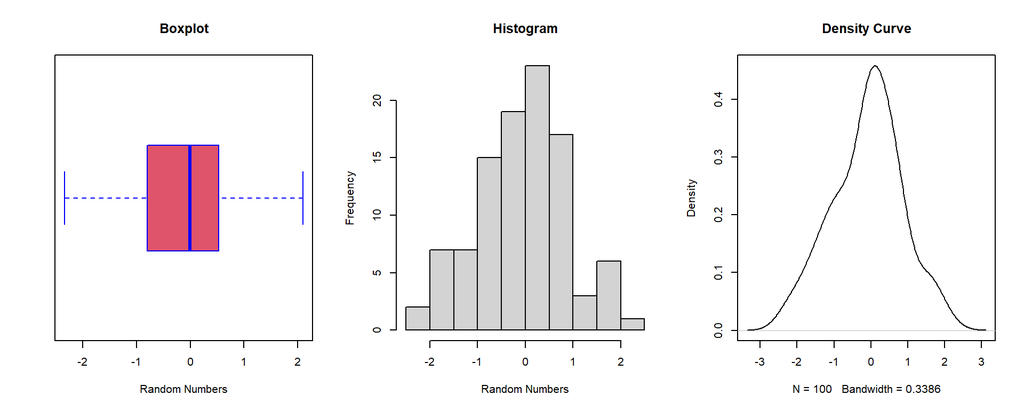

```r
par(mfrow=c(1,3)) # 1-by-3 layout
# subfigure #1
boxplot(x, horizontal=T, col=2, border="blue", xlab="Random Numbers", main="Boxplot")

# subfigure #2
hist(x, xlab="Random Numbers", main="Histogram")

# subfigure #3
plot(density(x), main="Density Curve")
```